# Poisson Regression for Biking counts on NYC bridges

Zackary Petrasek

10/31/2026

# 1 Description of the Data and Variables

The data comes from the Traffic Information Management System, looking at cyclist counts from the Queens, Manhattan, Williamsburg, and Brooklyn bridges for each day in July of 2017. As July has 31 days the data set has 31 observations. This data set specifically looks at the count for the Brooklyn Bridge (`BrooklynBridge`) and the total count for all four combined (`Total`). The predictor variables are Day of the week (`Day`), amount of precipitation (`Precipitation`), and High temperature and low temperature for the day (`HighTemp` and `LowTemp` respectively).

## 1.1 Reading and cleaning the data

The Excel file stored dates as serial numbers, so `Date` and `Day` did not come through correctly. I first removed the `Date` variable after using it to rebuild `Day` as it is simply an observation number. I then changed `Day` to simply be weekend or weekday. I also removed the `HighTemp` and `LowTemp` variables, and created a `Temp` variable to check if the temperature on the day was high or low in comparison to the rest of the month, with 84 degrees Fahrenheit being the cut off. I also transformed `Precipitation` into a binary variable on if there was precipitation on the day or not. I then turned all of these variables into factors to put into the models.

```r
# 1. Read sheet 'data4' (Brooklyn Bridge, July 2017) straight from the course website
dat <- read.xlsx("https://zackarypetrasek.github.io/STA321/homeworks/hw6/w09-AssignDataSet.xlsx",
                 sheet = "data4")

# 2. Column names in this sheet have trailing spaces (e.g. "HighTemp "),
#    which read.xlsx turns into dots. Keep letters only: "HighTemp", "LowTemp", ...
names(dat) <- gsub("[^A-Za-z]", "", names(dat))

# 3. Excel stores dates as serial numbers (42917 = July 1, 2017). Convert them back.
dat$Date <- as.Date(as.numeric(dat$Date), origin = "1899-12-30")

# 4. Rebuild Day from the real calendar date.
#    format(..., "%u") gives 1 = Monday ... 6 = Saturday, 7 = Sunday
dat$Day <- ifelse(format(dat$Date, "%u") %in% c("6", "7"), "Weekend", "Weekday")

# 5. Discretize the weather variables
dat$Precip <- ifelse(dat$Precipitation > 0, "Yes", "No")   # any rain at all?
dat$Temp   <- ifelse(dat$HighTemp > 84, "High", "Low")     # hot day (high above 84F) or not

# 6. Keep only the variables used in the models. Turn the categories into factors and
#    set the reference (baseline) level, because every coefficient is interpreted
#    relative to it: Weekday, no precipitation, low temperature.
biking <- data.frame(
  Day           = factor(dat$Day,    levels = c("Weekday", "Weekend")),
  Precipitation = factor(dat$Precip, levels = c("No", "Yes")),
  Temp          = factor(dat$Temp,   levels = c("Low", "High")),
  BrooklynBridge = dat$BrooklynBridge,                        # response: daily count
  Total          = dat$Total                                  # all four bridges (used as the offset)
)
```

## 1.2 Variable definitions

A final list of our variables we are using:

- `Day` (Weekday/Weekend, Weekday is the base level)
- `Precipitation` (Yes/No, No is the base level)
- `Temp` (High if the daily high is above 84F, otherwise Low, Low is the base level)
- `BrooklynBridge` (number of cyclists crossing the Brooklyn Bridge that day, the response)
- `Total` (cyclists across all four bridges that day, to calculate rate)

```r
# Quick look at the data: sample sizes in each category and the distribution of the counts
summary(biking)
```

```
      Day     Precipitation   Temp    BrooklynBridge     Total
 Weekday:21   No :23        Low :16   Min.   : 907   Min.   : 8210
 Weekend:10   Yes: 8        High:15   1st Qu.:2394   1st Qu.:14618
                                      Median :2860   Median :18696
                                      Mean   :2756   Mean   :18805
                                      3rd Qu.:3180   3rd Qu.:22979
                                      Max.   :3821   Max.   :26969
```

```r
kable(table(Day=biking$Day, Precipitation=biking$Precipitation, Temp=biking$Temp), caption = "Days by Day type, Temperature and Precipitation")
```

Days by Day type, Temperature and Precipitation

| Day | Precipitation | Temp | Freq |
| --- | --- | --- | --- |
| Weekday | No | Low | 7 |
| Weekend | No | Low | 5 |
| Weekday | Yes | Low | 3 |
| Weekend | Yes | Low | 1 |
| Weekday | No | High | 9 |
| Weekend | No | High | 2 |
| Weekday | Yes | High | 2 |
| Weekend | Yes | High | 2 |

Overall, it seems like precipitation having a yes value is a slightly rare occurrence, with only 8 observations. Looking at the combination of the predictor variables both weekend and weekday with high temp and precipitation had two observations each, which is pretty low and does not give us a lot of information on those type of days. Even lower is weekend days with low temperature and precipitation, which only had one observation, so all of our information on that type of day comes from a singular observation.

# 2 Research Question

The research questions for this assignment are:

1. Does the **number** of cyclists on the Brooklyn Bridge differ between weekdays and weekends, rainy and dry days, and hot and cooler days? The response variable is `BrooklynBridge`.
2. Does the **share** of all cyclists who use the Brooklyn Bridge (Brooklyn Bridge count compared four-bridge total count) change with the same factors? The response variable is `BrooklynBridge`/`Total`.

# 3 Statistical Models

Our two models, and questions, thus have different response variables. **BrooklynBridge** (daily count) for model and question 1, and the rate **BrooklynBridge / Total** for model and question 2. Both models will be poisson regression models with our three predictor variables, `Day`, `Precipitation`, and `Temp`.

## 3.1 Poisson regression: assumptions and idea

The assumptions we have when making a poisson model are:

- The response is a **count**: The response variable must be a count per a unit of time or space, which can be described by a poisson distribution.
- Log linearity: The log of the mean rate, must be a linear function of x.
- Independence: The observations are independent.
- Equal mean and variance: A poisson random variable, by definition, must have its mean and variance be equal to each other.
- Rate version: add an **offset** log(Total) so the model describes the proportion of cyclists on this bridge.

## 3.2 Poisson regression on the counts only

We will first start with the model which only looks at the counts. We will see which, if any, of our three factors significantly change the expected number of cyclists on the Brooklyn Bridge.

### 3.2.1 Full model

```r
# Fit the Poisson regression with all three predictors.
# family = poisson(link = "log") is the standard count model.
count.full <- glm(BrooklynBridge ~ Day + Precipitation + Temp,
                  family = poisson(link = "log"), data = biking)
kable(summary(count.full)$coef, caption = "Full Poisson count model")
```

Full Poisson count model

|  | Estimate | Std. Error | z value | Pr(>\|z\|) |
| --- | --- | --- | --- | --- |
| (Intercept) | 7.9919209 | 0.0057845 | 1381.610610 | 0 |
| DayWeekend | -0.0563335 | 0.0075508 | -7.460588 | 0 |
| PrecipitationYes | -0.4074059 | 0.0087868 | -46.365727 | 0 |
| TempHigh | 0.0758745 | 0.0069246 | 10.957244 | 0 |

In this model we can see that the p-values for all of our factors are effectively 0, with huge z-scores. This means that all the factors are significantly changing the expected value of cyclists according to this model. Due to this we do not need to do variable selection.

### 3.2.2 Interpretation of the coefficients

```r
# exp(coefficient) = multiplicative change in the EXPECTED COUNT
# (relative to the baseline: Weekday, no precipitation, low temperature).
# confint.default() gives Wald 95% confidence intervals on the log scale, then we exponentiate.
est <- cbind(Estimate = coef(count.full), confint.default(count.full))
kable(round(exp(est), 3), caption = "Multiplicative effects on the expected daily count (95% CI)")
```

Multiplicative effects on the expected daily count (95% CI)

|  | Estimate | 2.5 % | 97.5 % |
| --- | --- | --- | --- |
| (Intercept) | 2956.972 | 2923.637 | 2990.687 |
| DayWeekend | 0.945 | 0.931 | 0.959 |
| PrecipitationYes | 0.665 | 0.654 | 0.677 |
| TempHigh | 1.079 | 1.064 | 1.094 |

This means that for the model based on count of cyclist on the Brooklyn Bridge:

- $e^{\hat\beta}$ for `PrecipitationYes` is 0.665, with a 95% confidence interval of 0.654 to 0.677 so on rainy days the expected count is about 32.3 to 34.6% lower than on dry days holding all other factors constant.
- $e^{\hat\beta}$ for `DayWeekend` is 0.945, with a 95% confidence interval of 0.931 to 0.959 so on weekends the expected count is about 4.1% to 6.9% lower than on weekdays holding all other factors constant.
- $e^{\hat\beta}$ for `TempHigh` is 1.079, with a 95% confidence interval of 1.064 to 1.094 so on hotter days the expected count is about 6.4% to 9.4% higher than on cooler days holding all other factors constant.

## 3.3 Poisson regression on the rates

Another way to look at this is that the number of Brooklyn Bridge cyclists depends on how many cyclists are out that day. Modelling the **proportion** `BrooklynBridge / Total` asks the question: do these factors shift cyclists toward or away from the Brooklyn Bridge?

### 3.3.1 Full rate model

```r
# Same predictors, but with offset = log(Total).
# The offset is a term whose coefficient is fixed at 1, so the model is
#   log(count) = log(Total) + b0 + b1*x1 + ...   <=>   log(count / Total) = b0 + b1*x1 + ...
rate.final <- glm(BrooklynBridge ~ Day + Precipitation + Temp,
                 offset = log(Total),
                 family = poisson(link = "log"), data = biking)
kable(summary(rate.final)$coef, caption = "Full Poisson rate model")
```

Full Poisson rate model

|  | Estimate | Std. Error | z value | Pr(>\|z\|) |
| --- | --- | --- | --- | --- |
| (Intercept) | -1.9745743 | 0.0057489 | -343.469237 | 0.0000000 |
| DayWeekend | 0.1657823 | 0.0076181 | 21.761497 | 0.0000000 |
| PrecipitationYes | -0.0174130 | 0.0088584 | -1.965711 | 0.0493320 |
| TempHigh | 0.0198748 | 0.0069851 | 2.845325 | 0.0044366 |

Looking at this summary we can see that all three variables have a significant impact on the rate so no variables need to be dropped. However, it is important to note that Precipitation has a p-value of 0.049 so it is close to not being significant.

### 3.3.2 Interpretation of the coefficients

```r
# exp(coefficient) = RATE RATIO: the multiplicative change in the share of all cyclists
# who use the Brooklyn Bridge, relative to the baseline day.
est.rate <- cbind(Estimate = coef(rate.final), confint.default(rate.final))
kable(round(exp(est.rate), 3), caption = "Rate ratios for the Brooklyn Bridge share (95% CI)")
```

Rate ratios for the Brooklyn Bridge share (95% CI)

|  | Estimate | 2.5 % | 97.5 % |
| --- | --- | --- | --- |
| (Intercept) | 0.139 | 0.137 | 0.140 |
| DayWeekend | 1.180 | 1.163 | 1.198 |
| PrecipitationYes | 0.983 | 0.966 | 1.000 |
| TempHigh | 1.020 | 1.006 | 1.034 |

This means that for the model based on rate of cyclist on the Brooklyn Bridge compared to all bridges:

- $e^{\hat\beta}$ for `PrecipitationYes` is .983, with a 95% confidence interval of .966 to 1, so on rainy days the expected rate is between about 3.4% lower and no different from dry days (as the interval touches 1), holding all other factors constant.
- $e^{\hat\beta}$ for `DayWeekend` is 1.18, with a 95% confidence interval of 1.163 to 1.198 so on weekends the expected rate is about 16.3% to 19.8% higher than on weekdays holding all other factors constant.
- $e^{\hat\beta}$ for `TempHigh` is 1.02, with a 95% confidence interval of 1.006 to 1.034 so on hotter days the expected rate is about 0.6% to 3.4% higher than on cooler days holding all other factors constant.

## 3.4 Graphical comparison of the rate across all three factors

The rate model has three factors (Day, Precipitation, Temp), so there are 2 x 2 x 2 = 8 kinds of days. The plot below shows the model’s predicted share of all cyclists who use the Brooklyn Bridge for every one of those 8 combinations. Each panel is one temperature level, the groups of bars are weekday vs. weekend, and the two bar colors are dry vs. rainy. The black lines are 95% confidence intervals for the predicted share, and the diamonds are the shares we actually observed on those days.

```r
# Predicted share for every combination of Day, Precipitation, and Temp (8 combinations).
grid <- expand.grid(Day = levels(biking$Day),
                    Precipitation = levels(biking$Precipitation),
                    Temp = levels(biking$Temp))
grid$Total <- 1    # offset = log(1) = 0, so type = "link" gives log(rate) directly

# Predict on the log scale with standard errors, then exponentiate to get the rate
# and a 95% Wald confidence interval for it.
pred <- predict(rate.final, newdata = grid, type = "link", se.fit = TRUE)
grid$rate  <- exp(pred$fit)
grid$lower <- exp(pred$fit - 1.96 * pred$se.fit)
grid$upper <- exp(pred$fit + 1.96 * pred$se.fit)

# Observed share for each combination = (sum of Brooklyn Bridge counts) / (sum of all-bridge totals)
obs <- aggregate(cbind(BrooklynBridge, Total) ~ Day + Precipitation + Temp,
                 data = biking, FUN = sum)
obs$obs.rate <- obs$BrooklynBridge / obs$Total
grid <- merge(grid, obs[, c("Day", "Precipitation", "Temp", "obs.rate")],
              by = c("Day", "Precipitation", "Temp"), all.x = TRUE)

# Table of the 8 predicted shares (in %)
tab <- grid[, c("Day", "Precipitation", "Temp")]
tab$Predicted  <- round(100 * grid$rate, 1)
tab$Lower95    <- round(100 * grid$lower, 1)
tab$Upper95    <- round(100 * grid$upper, 1)
tab$Observed   <- round(100 * grid$obs.rate, 1)
tab$Days       <- as.vector(table(biking$Day, biking$Precipitation, biking$Temp)[
                    cbind(match(grid$Day, levels(biking$Day)),
                          match(grid$Precipitation, levels(biking$Precipitation)),
                          match(grid$Temp, levels(biking$Temp)))])
kable(tab, row.names = FALSE,
      caption = "Predicted and observed share (%) of cyclists on the Brooklyn Bridge")
```

Predicted and observed share (%) of cyclists on the Brooklyn Bridge

| Day | Precipitation | Temp | Predicted | Lower95 | Upper95 | Observed | Days |
| --- | --- | --- | --- | --- | --- | --- | --- |
| Weekday | No | High | 14.2 | 14.0 | 14.3 | 13.9 | 9 |
| Weekday | No | Low | 13.9 | 13.7 | 14.0 | 14.2 | 7 |
| Weekday | Yes | High | 13.9 | 13.7 | 14.2 | 15.2 | 2 |
| Weekday | Yes | Low | 13.6 | 13.4 | 13.9 | 12.2 | 3 |
| Weekend | No | High | 16.7 | 16.5 | 17.0 | 17.1 | 2 |
| Weekend | No | Low | 16.4 | 16.2 | 16.6 | 16.2 | 5 |
| Weekend | Yes | High | 16.4 | 16.1 | 16.7 | 15.8 | 2 |
| Weekend | Yes | Low | 16.1 | 15.8 | 16.4 | 17.5 | 1 |

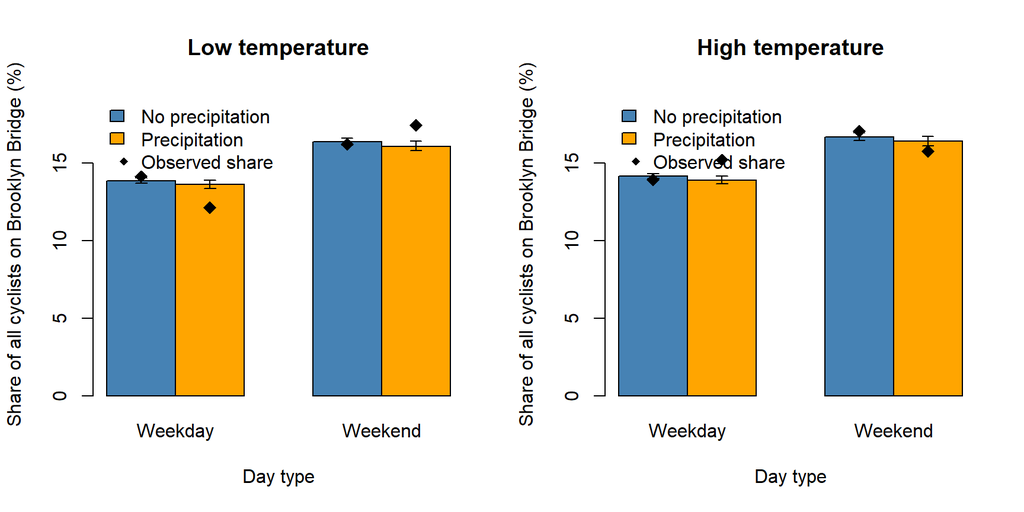

```r
# One panel per temperature level; bars grouped by Day, colored by Precipitation.
ymax <- max(grid$upper) * 100 * 1.15
par(mfrow = c(1, 2))
for (tmp in levels(biking$Temp)) {
  sub <- grid[grid$Temp == tmp, ]

  # helper: turn one column of 'sub' into a matrix with
  # rows = Precipitation (No, Yes) and columns = Day (Weekday, Weekend)
  cellmat <- function(col) {
    sapply(levels(biking$Day), function(d)
      sapply(levels(biking$Precipitation), function(p)
        sub[[col]][sub$Day == d & sub$Precipitation == p]))
  }

  mids <- barplot(cellmat("rate") * 100, beside = TRUE, ylim = c(0, ymax),
                  col = c("steelblue", "orange"),
                  xlab = "Day type",
                  ylab = "Share of all cyclists on Brooklyn Bridge (%)",
                  main = paste(tmp, "temperature"))
  arrows(mids, cellmat("lower") * 100, mids, cellmat("upper") * 100,
         angle = 90, code = 3, length = 0.05)               # 95% CI
  points(mids, cellmat("obs.rate") * 100, pch = 18, cex = 1.5)  # observed share
  legend("topleft", bty = "n",
         legend = c("No precipitation", "Precipitation", "Observed share"),
         fill = c("steelblue", "orange", NA), border = c("black", "black", NA),
         pch = c(NA, NA, 18))
}
```

```r
par(mfrow = c(1, 1))
```

The biggest difference in the plot is between weekdays and weekends. On a dry, cooler day the model predicts that about 13.9% of all cyclists use the Brooklyn Bridge on a weekday, compared with about 16.4% on a weekend. That is the rate ratio of 1.18 from the model, and it shows up in all four weather combinations, in both panels. The weather barely moves the share. Rain lowers the predicted share by only about 0.2 to 0.3 percentage points (for example 13.9% to 13.6% on a cooler weekday), and a hot day raises it by about 0.3 percentage points (13.9% to 14.2% on a dry weekday). The highest predicted share is on dry, hot weekends (about 16.7%) and the lowest is on rainy, cooler weekdays (about 13.6%). So even though the temperature and precipitation coefficients are statistically significant, the practical effect of weather on how cyclists split between bridges is very small compared with the day type.

Two cautions: some of these combinations contain only one or two days (see the Days column), so the diamonds for those groups rest on very little data. Also the observed shares fall outside the model’s intervals in most combinations, which fits the overdispersion: the intervals are too narrow. Still, every weekend day type has a higher observed share than every weekday day type, so the main finding doesn’t depend on the exact intervals.

# 4 Summary of Findings

To summarize the findings of the two models: